# Part 2: Machine Learning

## Conclusions 1st step

Working with this dataset has not been an easy thing. There were a few things that made it difficult and the main one was the fact that our target variable was Imbalanced, and not just a little bit. In this case the proportion was 97% of observations that were not in bankruptcy whereas only a 3% of them actually were.

When I first started working on the dataset (mainly in prepossess), I did not really know much about classification, therefore I didn’t thought that it was going to be a problem having this difference in proportions. Later, when I started working on the predictive models I realized that the dataset was not being very useful, due the fact that on every model the accuracy was over 0.96, as most of the observations were predicting as not being in bankruptcy and only a few of them were (between 6 and 9 observations).

As I have already worked a lot in this dataset, I could not start over with another different dataset so I focused my models on being able to get higher kappa, sensitivity, specificity and precision rates instead of focusing in the accuracy, which I really did not care about.

Then looking through different resources I found our about different methods to balance the data, and I apply them to this dataset, what brought me the possibility to build good classification models.

# 2nd Step Machine Learning methods

On this second step of the project we are going to use different Machine Learning methods to obtain our predictions about if a company is in bankruptcy or not.

We will test:

- Nearest Neighbors
- SVMs
- Decision trees
- Random Forest
- Gradient Boosting
- Neural Networks

## Nearest Neighbors

First of all we are going to test how well does knn work with our dataset. This method is very useful for non-linear data, which is our case. Nevertheless it works worse on data sets with high dimension. We are also going to use cross validation over it with the same train control selected in the first step, a “repeatedcv” for 4 times.

Due to the final goal of our analysis I will keep the kappa as an accuracy method. In order to use the optimal method we will do hyperparameter tunning, so we know that the model used is the best one for our data. Using the function in caret we can already train our model with the optimal number of neighbors for the model.

```r
knnFit <- train(Bankrupt. ~ .,
                method = "knn",
                data = trainSet2,
                preProcess = c("center", "scale"),
                tuneLength = 5,
                metric = "Kappa",
                trControl = ctrl)
print(knnFit)
```

```
## k-Nearest Neighbors
##
## 4874 samples
##    7 predictor
##    2 classes: '0', '1'
##
## Pre-processing: centered (7), scaled (7)
## Resampling: Cross-Validated (7 fold, repeated 4 times)
## Summary of sample sizes: 4178, 4178, 4177, 4177, 4178, 4178, ...
## Resampling results across tuning parameters:
##
##   k   Accuracy   Kappa
##    5  0.9318832  0.8568002
##    7  0.9150087  0.8230281
##    9  0.9016737  0.7967107
##   11  0.8932605  0.7799620
##   13  0.8873101  0.7677556
##
## Kappa was used to select the optimal model using the largest value.
## The final value used for the model was k = 5.
```

We can see that the best result is given when k=5, as both Accuracy and Kappa are the best ones obtained. This optimal k will be the one used to train our model.

```r
knnPred = predict(knnFit, testSet2)
confusionMatrix(knnPred,testSet2$Bankrupt.)
```

```
## Confusion Matrix and Statistics
##
##           Reference
## Prediction   0   1
##          0 718   0
##          1  74 426
##
##                Accuracy : 0.9392
##                  95% CI : (0.9243, 0.952)
##     No Information Rate : 0.6502
##     P-Value [Acc > NIR] : < 2.2e-16
##
##                   Kappa : 0.8716
##
##  Mcnemar's Test P-Value : < 2.2e-16
##
##             Sensitivity : 0.9066
##             Specificity : 1.0000
##          Pos Pred Value : 1.0000
##          Neg Pred Value : 0.8520
##              Prevalence : 0.6502
##          Detection Rate : 0.5895
##    Detection Prevalence : 0.5895
##       Balanced Accuracy : 0.9533
##
##        'Positive' Class : 0
##
```

Given the confusion matrix for the prediction and the real values we can see that the results obtained are very promising, indeed, this is the best prediction obtained so far. We can see that we are obtained an accuracy of almost an 94% and the error of the prediction is only given in companies that are predicted as Bankruptcy that are not. This is the best case for this dataset as my goal as it will be much worse predicting a company that is in Bankruptcy as not than the other way.

Also, those companies that are being predicted as Bankruptcy could mean that even though they are not declared as Bankruptcy they might be very close to it, so giving a prediction of being Bankruptcy could not be that bad at all if we are seeing it from a investors point of view.

## Support Vector Machines

Now we are going to see how support vector machines works with our data. Again, we are going to do hyperparameter tunning in order to obtain the best parameters for our dataset.

First we are going to see how good it works for non optimal parameters.

```r
svm.train <- svm(Bankrupt.~., data=trainSet2, scale=T, kernel="sigmoid",
                 gamma=0.01, cost=1)
svm.pred <- predict(svm.train, newdata=testSet2)
confusionMatrix(svm.pred, testSet2$Bankrupt.)
```

```
## Confusion Matrix and Statistics
##
##           Reference
## Prediction   0   1
##          0 725  89
##          1  67 337
##
##                Accuracy : 0.8719
##                  95% CI : (0.8518, 0.8902)
##     No Information Rate : 0.6502
##     P-Value [Acc > NIR] : <2e-16
##
##                   Kappa : 0.715
##
##  Mcnemar's Test P-Value : 0.0927
##
##             Sensitivity : 0.9154
##             Specificity : 0.7911
##          Pos Pred Value : 0.8907
##          Neg Pred Value : 0.8342
##              Prevalence : 0.6502
##          Detection Rate : 0.5952
##    Detection Prevalence : 0.6683
##       Balanced Accuracy : 0.8532
##
##        'Positive' Class : 0
##
```

We can see that the results are not bad at all compared to the methods that we used in the first step. However, when compared to knn, the results are worse. Now we are going to see if we can make it better using hyperparameter tunning. First of all we are going to use Support Vector Machines with Radial Basis Function Kernel method.

```r
svmFit_rad <- train(Bankrupt. ~., method = "svmRadial",
                data = trainSet2,
                preProcess = c("center", "scale"),
                tuneGrid = expand.grid(C = c(0.1, .25, .5, 1),
                                      sigma = c(0.01,.05,0.1)),
                metric = "Kappa",
                trControl = ctrl)

svmRadPred = predict(svmFit_rad, testSet2)
confusionMatrix(svmRadPred,testSet2$Bankrupt.)
```

```
## Confusion Matrix and Statistics
##
##           Reference
## Prediction   0   1
##          0 724  73
##          1  68 353
##
##                Accuracy : 0.8842
##                  95% CI : (0.8649, 0.9017)
##     No Information Rate : 0.6502
##     P-Value [Acc > NIR] : <2e-16
##
##                   Kappa : 0.7448
##
##  Mcnemar's Test P-Value : 0.7362
##
##             Sensitivity : 0.9141
##             Specificity : 0.8286
##          Pos Pred Value : 0.9084
##          Neg Pred Value : 0.8385
##              Prevalence : 0.6502
##          Detection Rate : 0.5944
##    Detection Prevalence : 0.6544
##       Balanced Accuracy : 0.8714
##
##        'Positive' Class : 0
##
```

## Decission Trees

As SVM did not workout as we wanted to we are going to try now with decision trees. Again, we are going to test a model optimized and another one with hyperparameter tunning.

```r
rpart.fit <- rpart(Bankrupt. ~., method="class", data = trainSet2)
rpart.pred <- predict(rpart.fit, newdata=testSet2,type="class")
confusionMatrix(rpart.pred, testSet2$Bankrupt.)
```

```
## Confusion Matrix and Statistics
##
##           Reference
## Prediction   0   1
##          0 718  38
##          1  74 388
##
##                Accuracy : 0.908
##                  95% CI : (0.8904, 0.9237)
##     No Information Rate : 0.6502
##     P-Value [Acc > NIR] : < 2.2e-16
##
##                   Kappa : 0.8017
##
##  Mcnemar's Test P-Value : 0.0009424
##
##             Sensitivity : 0.9066
##             Specificity : 0.9108
##          Pos Pred Value : 0.9497
##          Neg Pred Value : 0.8398
##              Prevalence : 0.6502
##          Detection Rate : 0.5895
##    Detection Prevalence : 0.6207
##       Balanced Accuracy : 0.9087
##
##        'Positive' Class : 0
##
```

Using an non optimized decision tree we can see that the accuracy has gotten higher. However, it is still lower than the one obtained with knn. Even though it is not the best model for our data it works pretty good and one of the benefits of using it is that you can easily get the scheme of how the model classifies companies as bankruptcy or not and get a better understanding of it.

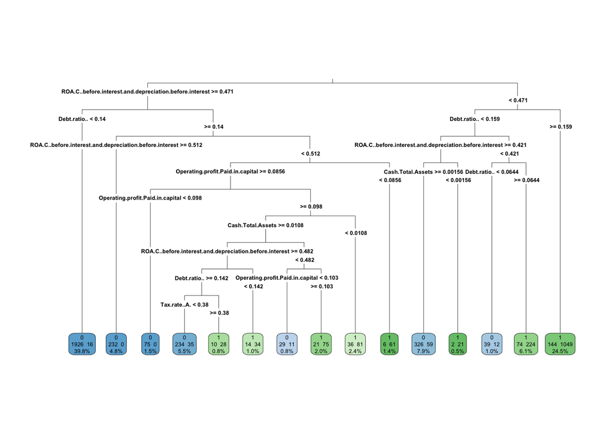

```r
rpart.plot(rpart.fit, digits = 3, fallen.leaves = TRUE,
           type = 3, extra=101)
```

Now we are going to build a model based on decision trees with hyperparameter tunning.

```r
grid_c50 <- expand.grid( .winnow = c(TRUE,FALSE), .trials=c(1,5,10,15,20),
                         .model="tree" )

fit.c50 <- train(Bankrupt. ~.,
                data=trainSet2,
                method="C5.0",
                metric="Kappa",
                tuneGrid = grid_c50,
                trControl = ctrl)
print(fit.c50)
```

```
## C5.0
##
## 4874 samples
##    7 predictor
##    2 classes: '0', '1'
##
## No pre-processing
## Resampling: Cross-Validated (7 fold, repeated 4 times)
## Summary of sample sizes: 4178, 4178, 4178, 4178, 4177, 4178, ...
## Resampling results across tuning parameters:
##
##   winnow  trials  Accuracy   Kappa
##   FALSE    1      0.9703018  0.9360214
##   FALSE    5      0.9813822  0.9595910
##   FALSE   10      0.9851765  0.9677465
##   FALSE   15      0.9858953  0.9693107
##   FALSE   20      0.9868698  0.9714116
##    TRUE    1      0.9702505  0.9359148
##    TRUE    5      0.9818440  0.9605826
##    TRUE   10      0.9855878  0.9686367
##    TRUE   15      0.9863571  0.9702996
##    TRUE   20      0.9871779  0.9720792
##
## Tuning parameter 'model' was held constant at a value of tree
## Kappa was used to select the optimal model using the largest value.
## The final values used for the model were trials = 20, model = tree and winnow
##  = TRUE.
```

```r
c50.pred <- predict(fit.c50, newdata=testSet2)
confusionMatrix(c50.pred, testSet2$Bankrupt.)
```

```
## Confusion Matrix and Statistics
##
##           Reference
## Prediction   0   1
##          0 778   0
##          1  14 426
##
##                Accuracy : 0.9885
##                  95% CI : (0.9808, 0.9937)
##     No Information Rate : 0.6502
##     P-Value [Acc > NIR] : < 2.2e-16
##
##                   Kappa : 0.9749
##
##  Mcnemar's Test P-Value : 0.000512
##
##             Sensitivity : 0.9823
##             Specificity : 1.0000
##          Pos Pred Value : 1.0000
##          Neg Pred Value : 0.9682
##              Prevalence : 0.6502
##          Detection Rate : 0.6388
##    Detection Prevalence : 0.6388
##       Balanced Accuracy : 0.9912
##
##        'Positive' Class : 0
##
```

Surprisingly the accuracy obtained in this model is almost 99%! Also the Kappa is very high, 97%. The model has been fitted using 20 trials and window as True. This numbers are going to be very difficult to improve as it is making almost a perfect classification, not only due to the accuracy but also to the fact that again it is not predicting any companies that are in Bankruptcy as not, which is one of the most important goals of our analysis.

## Random Forest

We are now going to test Random Forest and see if we get better or worse results than in the previous models. As we have been doing, we will first built a model without tuning parameters and another one tuning them.

```r
rf.train <- randomForest(Bankrupt. ~., data=trainSet2,
                         ntree=250,mtry=10,cutoff=c(0.5,0.5),
                         importance=TRUE, do.trace=T)
rf.pred <- predict(rf.train, newdata=testSet2)
confusionMatrix(rf.pred, testSet2$Bankrupt.)
```

```
## Confusion Matrix and Statistics
##
##           Reference
## Prediction   0   1
##          0 774   0
##          1  18 426
##
##                Accuracy : 0.9852
##                  95% CI : (0.9767, 0.9912)
##     No Information Rate : 0.6502
##     P-Value [Acc > NIR] : < 2.2e-16
##
##                   Kappa : 0.9678
##
##  Mcnemar's Test P-Value : 6.151e-05
##
##             Sensitivity : 0.9773
##             Specificity : 1.0000
##          Pos Pred Value : 1.0000
##          Neg Pred Value : 0.9595
##              Prevalence : 0.6502
##          Detection Rate : 0.6355
##    Detection Prevalence : 0.6355
##       Balanced Accuracy : 0.9886
##
##        'Positive' Class : 0
##
```

```r
rf.train <- train(Bankrupt. ~.,
                  method = "rf",
                  data = trainSet2,
                  preProcess = c("center", "scale"),
                  ntree = 250,
                  cutoff=c(0.5,0.5),
                  tuneGrid = expand.grid(mtry = c(10,20,30)),
                  metric = "Kappa",
                  trControl = ctrl)
print(rf.train)
```

```
## Random Forest
##
## 4874 samples
##    7 predictor
##    2 classes: '0', '1'
##
## Pre-processing: centered (7), scaled (7)
## Resampling: Cross-Validated (7 fold, repeated 4 times)
## Summary of sample sizes: 4177, 4178, 4178, 4177, 4178, 4178, ...
## Resampling results across tuning parameters:
##
##   mtry  Accuracy   Kappa
##   10    0.9835856  0.9643544
##   20    0.9835858  0.9643585
##   30    0.9835345  0.9642457
##
## Kappa was used to select the optimal model using the largest value.
## The final value used for the model was mtry = 20.
```

```r
rf.pred <- predict(rf.train, testSet2)
confusionMatrix(rf.pred, testSet2$Bankrupt.)
```

```
## Confusion Matrix and Statistics
##
##           Reference
## Prediction   0   1
##          0 778   0
##          1  14 426
##
##                Accuracy : 0.9885
##                  95% CI : (0.9808, 0.9937)
##     No Information Rate : 0.6502
##     P-Value [Acc > NIR] : < 2.2e-16
##
##                   Kappa : 0.9749
##
##  Mcnemar's Test P-Value : 0.000512
##
##             Sensitivity : 0.9823
##             Specificity : 1.0000
##          Pos Pred Value : 1.0000
##          Neg Pred Value : 0.9682
##              Prevalence : 0.6502
##          Detection Rate : 0.6388
##    Detection Prevalence : 0.6388
##       Balanced Accuracy : 0.9912
##
##        'Positive' Class : 0
##
```

## Gradient Boosting

Until now we have been testing methods both with and without hyperparameter tunning. However, the methods that we have left are more complex than the previous ones and setting default parameters are quite a random thing to do now. Therefore, from now on we will be using directly the functions from caret were it does the tunning automatically.

I am going to use now gradient boost method and see how it works on the data and which hyperparameters are the best ones.

```r
xgb_grid = expand.grid(
  nrounds = c(500,1000),
  eta = c(0.01, 0.001),
  max_depth = c(2, 4, 6),
  gamma = 1,
  colsample_bytree = c(0.2, 0.4),
  min_child_weight = c(1,5),
  subsample = 1
)

xgb.train = train(Bankrupt. ~ .,  data=testSet2,
                  trControl = ctrl,
                  metric="Kappa",
                  maximize = F,
                  tuneGrid = xgb_grid,
                  preProcess = c("center", "scale"),
                  method = "xgbTree"
)

xgb.pred <- predict(xgb.train, testSet2)
confusionMatrix(xgb.pred, testSet2$Bankrupt.)
```

```
## Confusion Matrix and Statistics
##
##           Reference
## Prediction   0   1
##          0 762 169
##          1  30 257
##
##                Accuracy : 0.8366
##                  95% CI : (0.8146, 0.857)
##     No Information Rate : 0.6502
##     P-Value [Acc > NIR] : < 2.2e-16
##
##                   Kappa : 0.6115
##
##  Mcnemar's Test P-Value : < 2.2e-16
##
##             Sensitivity : 0.9621
##             Specificity : 0.6033
##          Pos Pred Value : 0.8185
##          Neg Pred Value : 0.8955
##              Prevalence : 0.6502
##          Detection Rate : 0.6256
##    Detection Prevalence : 0.7644
##       Balanced Accuracy : 0.7827
##
##        'Positive' Class : 0
##
```

We can clearly see that this method does not really work with our data as good as other methods have been doing. This one of the lowest accuracy obtained so far and yet, it isn’t even that bad.

The problem with this model is that it is predicting a lot of companies as not being in Bankruptcy when they really are and this is what we want to avoid as much as possible.

If we incremented the grid we will probably obtain better results, however this will be computationally expensive and as we have gotten better results using simpler methods we will keep them instead of trying to make this fit our data.

## Neural Networks

Finally we are going to build two different methods using neural networks. This is one of the methods that is having more success in today’s real life applications. Therefore, the expectation of the results are incredible high.

First of all we are going to use a simple neural networks with just one hidden layer.

```r
nn.train <- train(Bankrupt. ~.,
                  method = "nnet",
                  data = trainSet2,
                  preProcess = c("center", "scale"),
                  MaxNWts = 1000,
                  maxit = 100,
                  tuneGrid = expand.grid(size=c(2,4,6), decay=c(0.01,0.001)),
                  metric = "Kappa",
                  maximize = F,
                  trControl = ctrl)
```

```r
nn.train$bestTune
```

```
##   size decay
## 2    2  0.01
```

```r
nn.pred <- predict(nn.train, testSet2)
confusionMatrix(nn.pred, testSet2$Bankrupt.)
```

```
## Confusion Matrix and Statistics
##
##           Reference
## Prediction   0   1
##          0 716  71
##          1  76 355
##
##                Accuracy : 0.8793
##                  95% CI : (0.8597, 0.8971)
##     No Information Rate : 0.6502
##     P-Value [Acc > NIR] : <2e-16
##
##                   Kappa : 0.7354
##
##  Mcnemar's Test P-Value : 0.7415
##
##             Sensitivity : 0.9040
##             Specificity : 0.8333
##          Pos Pred Value : 0.9098
##          Neg Pred Value : 0.8237
##              Prevalence : 0.6502
##          Detection Rate : 0.5878
##    Detection Prevalence : 0.6461
##       Balanced Accuracy : 0.8687
##
##        'Positive' Class : 0
##
```

As we can see the accuracy is not bad at all, but it is not the best one obtained so far. Indeed we are getting now false predictions over companies that are in bankruptcy and this is one of the things that we want to avoid, so this might not be the best one to use.

We are now going to add more hidden layers to improve the performance of the model. So we will be now fitting a model using deep neural networks.

```r
dnn.train <- train(Bankrupt. ~.,
                  method = "dnn",
                  data = trainSet2,
                  preProcess = c("center", "scale"),
                  numepochs = 20, # number of iterations on the whole training set
                  tuneGrid = expand.grid(layer1 = 1:4,
                                         layer2 = 0:2,
                                         layer3 = 0:2,
                                         hidden_dropout = 0,
                                         visible_dropout = 0),
                  metric = "Kappa",
                  maximize = F,
                  trControl = ctrl)
```

```r
dnn.pred <- predict(dnn.train, testSet2)
confusionMatrix(dnn.pred, testSet2$Bankrupt.)
```

```
## Confusion Matrix and Statistics
##
##           Reference
## Prediction   0   1
##          0 719  73
##          1  73 353
##
##                Accuracy : 0.8801
##                  95% CI : (0.8606, 0.8978)
##     No Information Rate : 0.6502
##     P-Value [Acc > NIR] : <2e-16
##
##                   Kappa : 0.7365
##
##  Mcnemar's Test P-Value : 1
##
##             Sensitivity : 0.9078
##             Specificity : 0.8286
##          Pos Pred Value : 0.9078
##          Neg Pred Value : 0.8286
##              Prevalence : 0.6502
##          Detection Rate : 0.5903
##    Detection Prevalence : 0.6502
##       Balanced Accuracy : 0.8682
##
##        'Positive' Class : 0
##
```

For this case, even though the accuracy is quite similar to the one obtained in the neural network with just one hidden layer, we can see how the predictions based on our goals are slightly worse than the other.

## Best Machine Learning Model

Since we started this second part we have been testing a partition from our data once it was balanced. However the real test should be made over the test partition that we did over our original dataset, which was very unbalanced.

Therefore, along all this machine learning methods that has been fitted from a balaced dataset, I am going to see which one of them give a better performance for this test partition and try to optimize it as much as possible.

As expected, the best methods are always those which have been built using hyperparameter tunning, so we will only check those in this step.

### KNN

```r
knn.Pred.final = predict(knnFit, testSet)
confusionMatrix(knn.Pred.final,testSet$Bankrupt.)
```

```
## Confusion Matrix and Statistics
##
##           Reference
## Prediction    0    1
##          0 2381   25
##          1  258   63
##
##                Accuracy : 0.8962
##                  95% CI : (0.8842, 0.9074)
##     No Information Rate : 0.9677
##     P-Value [Acc > NIR] : 1
##
##                   Kappa : 0.2711
##
##  Mcnemar's Test P-Value : <2e-16
##
##             Sensitivity : 0.9022
##             Specificity : 0.7159
##          Pos Pred Value : 0.9896
##          Neg Pred Value : 0.1963
##              Prevalence : 0.9677
##          Detection Rate : 0.8731
##    Detection Prevalence : 0.8823
##       Balanced Accuracy : 0.8091
##
##        'Positive' Class : 0
##
```

### SVM

```r
svm.Pred.final = predict(svmFit_rad, testSet)
confusionMatrix(svm.Pred.final,testSet$Bankrupt.)
```

```
## Confusion Matrix and Statistics
##
##           Reference
## Prediction    0    1
##          0 2353   22
##          1  286   66
##
##                Accuracy : 0.8871
##                  95% CI : (0.8746, 0.8987)
##     No Information Rate : 0.9677
##     P-Value [Acc > NIR] : 1
##
##                   Kappa : 0.2619
##
##  Mcnemar's Test P-Value : <2e-16
##
##             Sensitivity : 0.8916
##             Specificity : 0.7500
##          Pos Pred Value : 0.9907
##          Neg Pred Value : 0.1875
##              Prevalence : 0.9677
##          Detection Rate : 0.8629
##    Detection Prevalence : 0.8709
##       Balanced Accuracy : 0.8208
##
##        'Positive' Class : 0
##
```

### Decision Trees

```r
c50.pred.final <- predict(fit.c50, newdata=testSet)
confusionMatrix(c50.pred.final, testSet$Bankrupt.)
```

```
## Confusion Matrix and Statistics
##
##           Reference
## Prediction    0    1
##          0 2580   57
##          1   59   31
##
##                Accuracy : 0.9575
##                  95% CI : (0.9492, 0.9647)
##     No Information Rate : 0.9677
##     P-Value [Acc > NIR] : 0.9985
##
##                   Kappa : 0.3263
##
##  Mcnemar's Test P-Value : 0.9260
##
##             Sensitivity : 0.9776
##             Specificity : 0.3523
##          Pos Pred Value : 0.9784
##          Neg Pred Value : 0.3444
##              Prevalence : 0.9677
##          Detection Rate : 0.9461
##    Detection Prevalence : 0.9670
##       Balanced Accuracy : 0.6650
##
##        'Positive' Class : 0
##
```

### Random Forest

```r
rf.pred.final <- predict(rf.train, testSet)
confusionMatrix(rf.pred.final, testSet$Bankrupt.)
```

```
## Confusion Matrix and Statistics
##
##           Reference
## Prediction    0    1
##          0 2574   55
##          1   65   33
##
##                Accuracy : 0.956
##                  95% CI : (0.9476, 0.9634)
##     No Information Rate : 0.9677
##     P-Value [Acc > NIR] : 0.9996
##
##                   Kappa : 0.3321
##
##  Mcnemar's Test P-Value : 0.4113
##
##             Sensitivity : 0.9754
##             Specificity : 0.3750
##          Pos Pred Value : 0.9791
##          Neg Pred Value : 0.3367
##              Prevalence : 0.9677
##          Detection Rate : 0.9439
##    Detection Prevalence : 0.9641
##       Balanced Accuracy : 0.6752
##
##        'Positive' Class : 0
##
```

### Gradient Boosting

```r
xgb.pred.final <- predict(xgb.train, testSet)
confusionMatrix(xgb.pred.final, testSet$Bankrupt.)
```

```
## Confusion Matrix and Statistics
##
##           Reference
## Prediction    0    1
##          0 2504   40
##          1  135   48
##
##                Accuracy : 0.9358
##                  95% CI : (0.926, 0.9447)
##     No Information Rate : 0.9677
##     P-Value [Acc > NIR] : 1
##
##                   Kappa : 0.3248
##
##  Mcnemar's Test P-Value : 1.197e-12
##
##             Sensitivity : 0.9488
##             Specificity : 0.5455
##          Pos Pred Value : 0.9843
##          Neg Pred Value : 0.2623
##              Prevalence : 0.9677
##          Detection Rate : 0.9182
##    Detection Prevalence : 0.9329
##       Balanced Accuracy : 0.7471
##
##        'Positive' Class : 0
##
```

### Neural networks

```r
nn.pred.final <- predict(nn.train, testSet)
confusionMatrix(nn.pred.final, testSet$Bankrupt.)
```

```
## Confusion Matrix and Statistics
##
##           Reference
## Prediction    0    1
##          0 2287   18
##          1  352   70
##
##                Accuracy : 0.8643
##                  95% CI : (0.8509, 0.877)
##     No Information Rate : 0.9677
##     P-Value [Acc > NIR] : 1
##
##                   Kappa : 0.2336
##
##  Mcnemar's Test P-Value : <2e-16
##
##             Sensitivity : 0.8666
##             Specificity : 0.7955
##          Pos Pred Value : 0.9922
##          Neg Pred Value : 0.1659
##              Prevalence : 0.9677
##          Detection Rate : 0.8387
##    Detection Prevalence : 0.8453
##       Balanced Accuracy : 0.8310
##
##        'Positive' Class : 0
##
```

As expected, all the methods give a very good prediction in general. However, I had our goals clearly defined since the project started. From an investors point of view, one of the most important things is not predicting companies that are in bankruptcy as they are not, so our goal is to minimize the error of predicting 0 when 1 is the real value. Also, a high number on the other side of wrong classification is not a problem at all as those companies might be very close to being in bankruptcy even though they are not declared yet.

Following this goal we can see that the best models are the ones obtained using knn, svm and simple neural networks. Indeed, the neural network is already a really good model, however we are going to try to make it a little bit better using a threshold.

Notice that we have nor been using thresholds in this second part of the project. This is due to the fact that for almost all the confusion matrices, we have been obtaining very promising results. Some of them were that good that using thresholds would not make a difference in the model.

In order to select the best threshold we are going to use the same loop that we did for the first step.

```r
relative.cost <- c(1, 2, 0.5, 0.0)
CM = confusionMatrix(nn.pred.final, testSet$Bankrupt.)$table
sum(relative.cost*CM)
cost.i = matrix(NA, nrow = 10, ncol = 9)
j <- 0

for (threshold in seq(0.3,0.8,0.1)){

  j <- j + 1

  for(i in 1:10){
    # partition data intro training (80%) and testing sets (20%)
    d <- createDataPartition(trainSet2$Bankrupt., p = 0.8, list = FALSE)

    train<-trainSet2[d,]
    test <-trainSet2[-d,]

    nn.train_th <- train(Bankrupt. ~.,
                  method = "nnet",
                  data = train,
                  preProcess = c("center", "scale"),
                  MaxNWts = 1000,
                  maxit = 100,
                  tuneGrid = expand.grid(size=2, decay=0.01),
                  metric = "Kappa",
                  maximize = F,
                  trControl = ctrl)

    nn.Prob = predict(nn.train_th, test, type="prob")

    nnPred = rep(0, nrow(test))
    nnPred[which(nn.Prob[,2] > threshold)] = 1
    nnPred = factor(nnPred)

    CM = confusionMatrix(nnPred, test$Bankrupt.)$table

    cost.i[i,j] <- sum(relative.cost*CM)/nrow(test) # unitary cost
  }
}
```

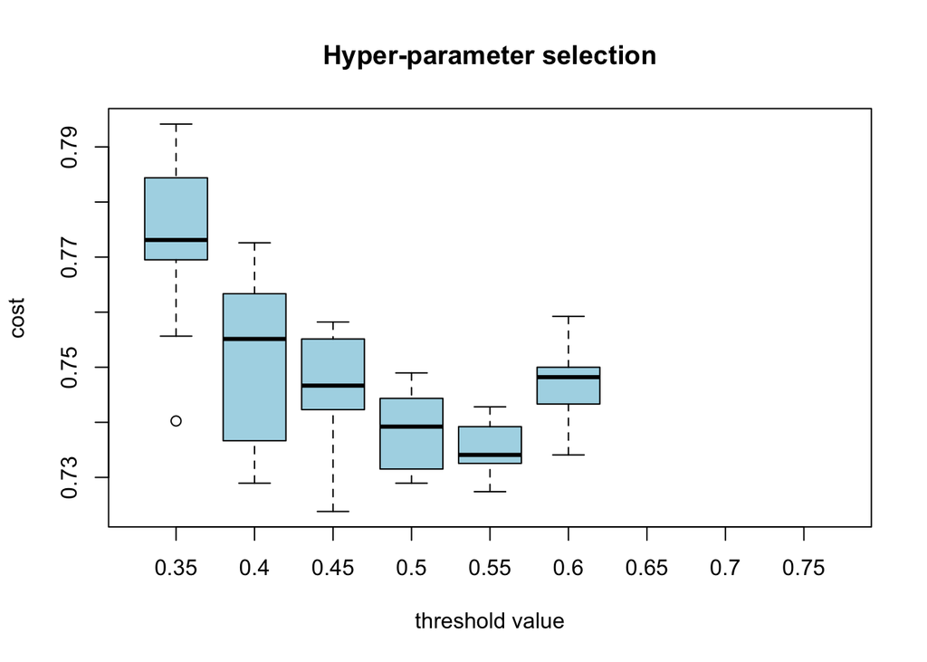

```r
boxplot(cost.i, main = "Hyper-parameter selection",
        ylab = "cost",
        xlab = "threshold value",names = seq(0.35,0.75,0.05),col="lightblue")
```

```r
threshold = 0.35
nnProb = predict(nn.train, newdata=testSet, type="prob")
nnPred = rep(0, nrow(testSet))
nnPred[which(nnProb[,2] > threshold)] = 1
confusionMatrix(as.factor(nnPred),testSet$Bankrupt.)
```

```
## Confusion Matrix and Statistics
##
##           Reference
## Prediction    0    1
##          0 2175   13
##          1  464   75
##
##                Accuracy : 0.8251
##                  95% CI : (0.8103, 0.8392)
##     No Information Rate : 0.9677
##     P-Value [Acc > NIR] : 1
##
##                   Kappa : 0.1945
##
##  Mcnemar's Test P-Value : <2e-16
##
##             Sensitivity : 0.8242
##             Specificity : 0.8523
##          Pos Pred Value : 0.9941
##          Neg Pred Value : 0.1391
##              Prevalence : 0.9677
##          Detection Rate : 0.7976
##    Detection Prevalence : 0.8023
##       Balanced Accuracy : 0.8382
##
##        'Positive' Class : 0
##
```

```r
threshold = 0.55
nnProb = predict(nn.train, newdata=testSet, type="prob")
nnPred = rep(0, nrow(testSet))
nnPred[which(nnProb[,2] > threshold)] = 1
confusionMatrix(as.factor(nnPred),testSet$Bankrupt.)
```

```
## Confusion Matrix and Statistics
##
##           Reference
## Prediction    0    1
##          0 2335   21
##          1  304   67
##
##                Accuracy : 0.8808
##                  95% CI : (0.8681, 0.8928)
##     No Information Rate : 0.9677
##     P-Value [Acc > NIR] : 1
##
##                   Kappa : 0.253
##
##  Mcnemar's Test P-Value : <2e-16
##
##             Sensitivity : 0.8848
##             Specificity : 0.7614
##          Pos Pred Value : 0.9911
##          Neg Pred Value : 0.1806
##              Prevalence : 0.9677
##          Detection Rate : 0.8563
##    Detection Prevalence : 0.8640
##       Balanced Accuracy : 0.8231
##
##        'Positive' Class : 0
##
```

## Conclusions 2nd Step

Along this second step I have had the opportunity to test several Machine Learning methods to do classification and it has been clearly shown that all of them work pretty good. Obviously some of them had a better performance with our dataset, but after all, most of them with our without hyperparameter tunnning ended up being good classification methods, with more than a 80% of accuracy for classification.

One of the biggest challenges that I have faced in this project is the grid definition for the hyperparameter tunning. Every method has different hyperparameters and it was quite difficult to understand which ranges should I give for each of them. Also, as some of this methods are very expensive in terms of computation, it happened that you could not give a very large grid search for some methods because they will take too long to fit the model.

Another point to mention is the fact that I was getting almost perfect results with some of our models when we were testing them with the balanced partition. Later on I realized that the classification was so “perfect” due to that the method used to balance the class was adding points pretty near to the ones that were original in the dataset, therefore, for methods like knn and svm, the classification was pretty easy. So, even though we still got good results with the original test, would have been nice to be able to fit the models with a real well balanced dataset.

# Best model

From both steps of the project we have ended with one model being the best one. However, which one is the best between these two?

```r
#LDA
lrProb = predict(ldaFit, newdata=testSet, type="prob")
lrPred = rep(0, nrow(testSet))
lrPred[which(lrProb[,2] > threshold)] = 1
lrPred = factor(lrPred)
confusionMatrix(lrPred,testSet$Bankrupt.)
```

```
## Confusion Matrix and Statistics
##
##           Reference
## Prediction    0    1
##          0 2402   24
##          1  237   64
##
##                Accuracy : 0.9043
##                  95% CI : (0.8926, 0.9151)
##     No Information Rate : 0.9677
##     P-Value [Acc > NIR] : 1
##
##                   Kappa : 0.2938
##
##  Mcnemar's Test P-Value : <2e-16
##
##             Sensitivity : 0.9102
##             Specificity : 0.7273
##          Pos Pred Value : 0.9901
##          Neg Pred Value : 0.2126
##              Prevalence : 0.9677
##          Detection Rate : 0.8808
##    Detection Prevalence : 0.8896
##       Balanced Accuracy : 0.8187
##
##        'Positive' Class : 0
##
```

```r
#Neural Network
confusionMatrix(as.factor(nnPred),testSet$Bankrupt.)
```

```
## Confusion Matrix and Statistics
##
##           Reference
## Prediction    0    1
##          0 2335   21
##          1  304   67
##
##                Accuracy : 0.8808
##                  95% CI : (0.8681, 0.8928)
##     No Information Rate : 0.9677
##     P-Value [Acc > NIR] : 1
##
##                   Kappa : 0.253
##
##  Mcnemar's Test P-Value : <2e-16
##
##             Sensitivity : 0.8848
##             Specificity : 0.7614
##          Pos Pred Value : 0.9911
##          Neg Pred Value : 0.1806
##              Prevalence : 0.9677
##          Detection Rate : 0.8563
##    Detection Prevalence : 0.8640
##       Balanced Accuracy : 0.8231
##
##        'Positive' Class : 0
##
```

Therefore, we can see that even though both predictions are very similar, we are actually obtaining slightly better results given our goal for the Neural network, as it is predicting a lower number of companies wrong. In the other hand, if we are considering the accuracy, then the LDA model is the best one.

# Conclusions

Through all this project I have came across several challenges that I have finally be able to deal with and that have made me learn different techniques and realize that on real life problems, datasets are not always perfect. I have also had the opportunity to apply every single classification method given in class and see its performance, compare them and analyze which one is better for each case.

As it can be seen, it does not exist a best final model, it will always depend on what you are looking for and the assumptions or risks that you want to take.

One of the points where I really saw that there was a big difference is the computational cost for all the Machine Learning models. It has always taken much longer to fit almost all the these methods than those from Probabilistic learning.

Finally, I can conclude by saying that this project has properly introduced me in some of the basic and most important parts for data Science.